# Practicum-3

Harsh

26/07/2020

```r
#Importing Libraries
library(caret)
library(psych)
library(neuralnet)
library(kernlab)
library(ROCR)
library(pROC)
```

1. Download the data set Bank Marketing Data Set. Note that the data file does not contain header names; you may wish to add those. The description of each column can be found in the data set explanation. Use the bank-additional-full.csv data set. Select an appropriate subset for testing. Use bank-additional.csv if your computer cannot process the full data set.
2. Explore the data set as you see fit and that allows you to get a sense of the data and get comfortable with it. Is there distributional skew in any of the features? Is there a need to apply a transform?
- Importing dataset using read.csv
- Using head,str and summary we verify whether there are any NA present or not
- To check the skewness first I used pairs.panels but images are short so cannot make any analysis
- So I plot histogram for each numerical feature and observed skewness for age and duration
- I used Log transform to adjust the skewness
- I converted all variables to numeric so that it is easy to use in neural network model

```r
#Importing Dataset
bank_data <- read.csv("C:\\Users\\harsh\\Desktop\\Introduction to Machine learning and Data Mining\\Practicum-3\\bank-additional-full.csv", sep = ';',stringsAsFactors = TRUE)

#Exploratory Analysis
head(bank_data)
```

|  | age | job | marital | education | default | housing | loan | contact | month | day_of_week | duration | campaign | pdays | previous | poutcome | emp.var.rate | cons.price.idx | cons.conf.idx | euribor3m | nr.employed | y |
| --- | --- | --- | --- | --- | --- | --- | --- | --- | --- | --- | --- | --- | --- | --- | --- | --- | --- | --- | --- | --- | --- |
| 1 | 56 | housemaid | married | basic.4y | no | no | no | telephone | may | mon | 261 | 1 | 999 | 0 | nonexistent | 1.1 | 93.994 | -36.4 | 4.857 | 5191 | no |
| 2 | 57 | services | married | high.school | unknown | no | no | telephone | may | mon | 149 | 1 | 999 | 0 | nonexistent | 1.1 | 93.994 | -36.4 | 4.857 | 5191 | no |
| 3 | 37 | services | married | high.school | no | yes | no | telephone | may | mon | 226 | 1 | 999 | 0 | nonexistent | 1.1 | 93.994 | -36.4 | 4.857 | 5191 | no |
| 4 | 40 | admin. | married | basic.6y | no | no | no | telephone | may | mon | 151 | 1 | 999 | 0 | nonexistent | 1.1 | 93.994 | -36.4 | 4.857 | 5191 | no |
| 5 | 56 | services | married | high.school | no | no | yes | telephone | may | mon | 307 | 1 | 999 | 0 | nonexistent | 1.1 | 93.994 | -36.4 | 4.857 | 5191 | no |
| 6 | 45 | services | married | basic.9y | unknown | no | no | telephone | may | mon | 198 | 1 | 999 | 0 | nonexistent | 1.1 | 93.994 | -36.4 | 4.857 | 5191 | no |

```r
str(bank_data)
```

```
## 'data.frame':    41188 obs. of  21 variables:
##  $ age           : int  56 57 37 40 56 45 59 41 24 25 ...
##  $ job           : Factor w/ 12 levels "admin.","blue-collar",..: 4 8 8 1 8 8 1 2 10 8 ...
##  $ marital       : Factor w/ 4 levels "divorced","married",..: 2 2 2 2 2 2 2 2 3 3 ...
##  $ education     : Factor w/ 8 levels "basic.4y","basic.6y",..: 1 4 4 2 4 3 6 8 6 4 ...
##  $ default       : Factor w/ 3 levels "no","unknown",..: 1 2 1 1 1 2 1 2 1 1 ...
##  $ housing       : Factor w/ 3 levels "no","unknown",..: 1 1 3 1 1 1 1 1 3 3 ...
##  $ loan          : Factor w/ 3 levels "no","unknown",..: 1 1 1 1 3 1 1 1 1 1 ...
##  $ contact       : Factor w/ 2 levels "cellular","telephone": 2 2 2 2 2 2 2 2 2 2 ...
##  $ month         : Factor w/ 10 levels "apr","aug","dec",..: 7 7 7 7 7 7 7 7 7 7 ...
##  $ day_of_week   : Factor w/ 5 levels "fri","mon","thu",..: 2 2 2 2 2 2 2 2 2 2 ...
##  $ duration      : int  261 149 226 151 307 198 139 217 380 50 ...
##  $ campaign      : int  1 1 1 1 1 1 1 1 1 1 ...
##  $ pdays         : int  999 999 999 999 999 999 999 999 999 999 ...
##  $ previous      : int  0 0 0 0 0 0 0 0 0 0 ...
##  $ poutcome      : Factor w/ 3 levels "failure","nonexistent",..: 2 2 2 2 2 2 2 2 2 2 ...
##  $ emp.var.rate  : num  1.1 1.1 1.1 1.1 1.1 1.1 1.1 1.1 1.1 1.1 ...
##  $ cons.price.idx: num  94 94 94 94 94 ...
##  $ cons.conf.idx : num  -36.4 -36.4 -36.4 -36.4 -36.4 -36.4 -36.4 -36.4 -36.4 -36.4 ...
##  $ euribor3m     : num  4.86 4.86 4.86 4.86 4.86 ...
##  $ nr.employed   : num  5191 5191 5191 5191 5191 ...
##  $ y             : Factor w/ 2 levels "no","yes": 1 1 1 1 1 1 1 1 1 1 ...
```

```r
summary(bank_data)
```

```
##       age                 job            marital
##  Min.   :17.00   admin.     :10422   divorced: 4612
##  1st Qu.:32.00   blue-collar: 9254   married :24928
##  Median :38.00   technician : 6743   single  :11568
##  Mean   :40.02   services   : 3969   unknown :   80
##  3rd Qu.:47.00   management : 2924
##  Max.   :98.00   retired    : 1720
##                  (Other)    : 6156
##                education        default         housing           loan
##  university.degree  :12168   no     :32588   no     :18622   no     :33950
##  high.school        : 9515   unknown: 8597   unknown:  990   unknown:  990
##  basic.9y           : 6045   yes    :    3   yes    :21576   yes    : 6248
##  professional.course: 5243
##  basic.4y           : 4176
##  basic.6y           : 2292
##  (Other)            : 1749
##       contact          month       day_of_week    duration
##  cellular :26144   may    :13769   fri:7827    Min.   :   0.0
##  telephone:15044   jul    : 7174   mon:8514    1st Qu.: 102.0
##                    aug    : 6178   thu:8623    Median : 180.0
##                    jun    : 5318   tue:8090    Mean   : 258.3
##                    nov    : 4101   wed:8134    3rd Qu.: 319.0
##                    apr    : 2632               Max.   :4918.0
##                    (Other): 2016
##     campaign          pdays          previous            poutcome
##  Min.   : 1.000   Min.   :  0.0   Min.   :0.000   failure    : 4252
##  1st Qu.: 1.000   1st Qu.:999.0   1st Qu.:0.000   nonexistent:35563
##  Median : 2.000   Median :999.0   Median :0.000   success    : 1373
##  Mean   : 2.568   Mean   :962.5   Mean   :0.173
##  3rd Qu.: 3.000   3rd Qu.:999.0   3rd Qu.:0.000
##  Max.   :56.000   Max.   :999.0   Max.   :7.000
##
##   emp.var.rate      cons.price.idx  cons.conf.idx     euribor3m
##  Min.   :-3.40000   Min.   :92.20   Min.   :-50.8   Min.   :0.634
##  1st Qu.:-1.80000   1st Qu.:93.08   1st Qu.:-42.7   1st Qu.:1.344
##  Median : 1.10000   Median :93.75   Median :-41.8   Median :4.857
##  Mean   : 0.08189   Mean   :93.58   Mean   :-40.5   Mean   :3.621
##  3rd Qu.: 1.40000   3rd Qu.:93.99   3rd Qu.:-36.4   3rd Qu.:4.961
##  Max.   : 1.40000   Max.   :94.77   Max.   :-26.9   Max.   :5.045
##
##   nr.employed     y
##  Min.   :4964   no :36548
##  1st Qu.:5099   yes: 4640
##  Median :5191
##  Mean   :5167
##  3rd Qu.:5228
##  Max.   :5228
##
```

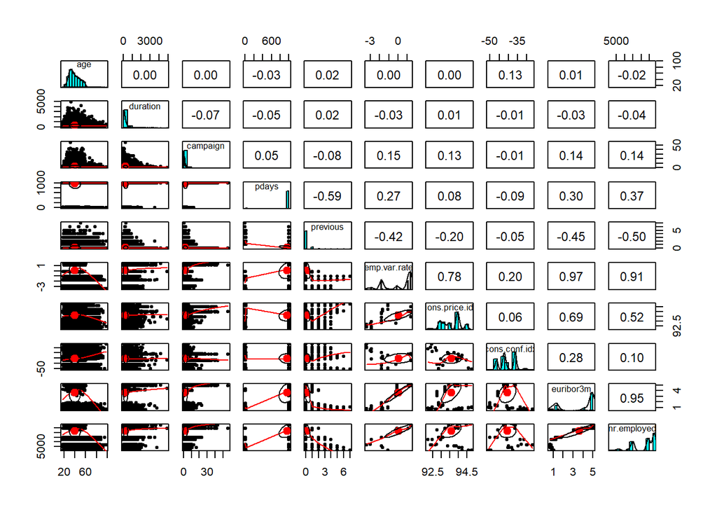

```r
pairs.panels(bank_data[,c(1,11,12,13,14,16,17,18,19,20)])
```

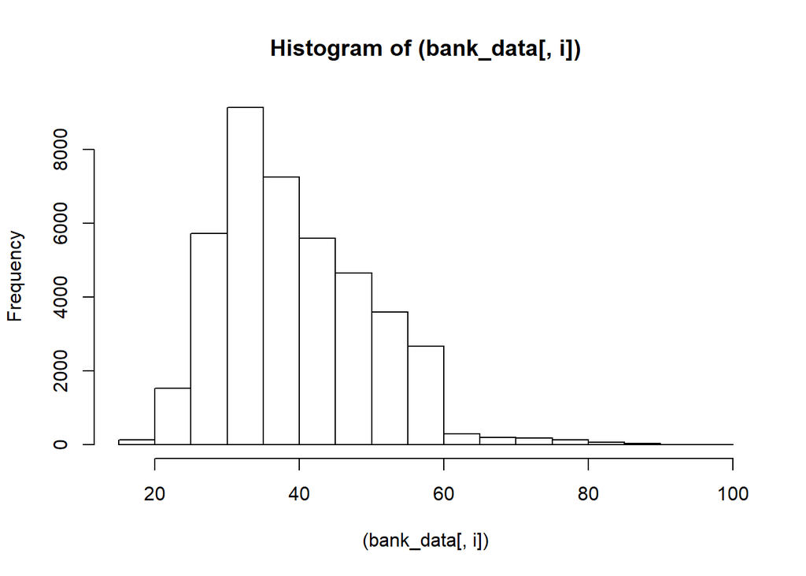

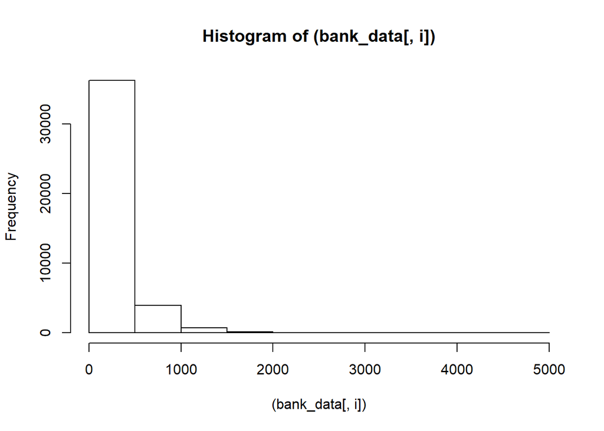

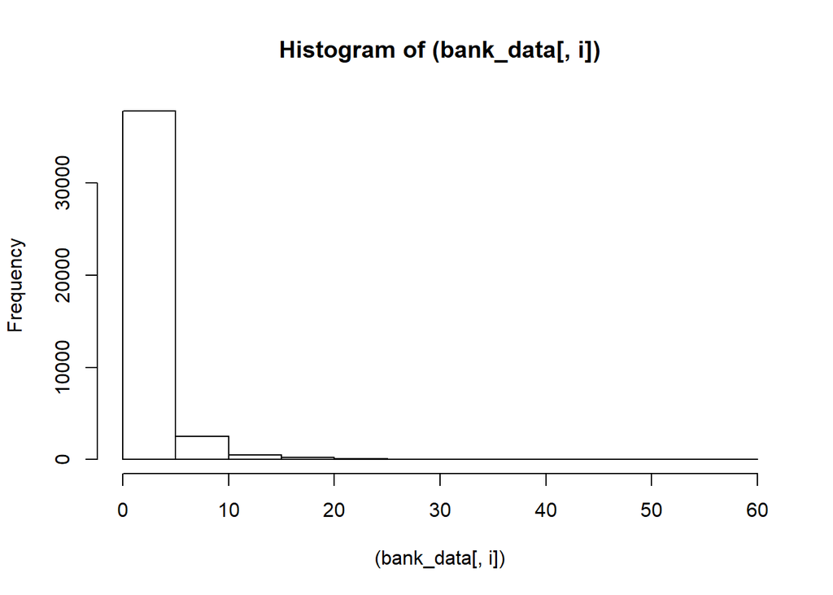

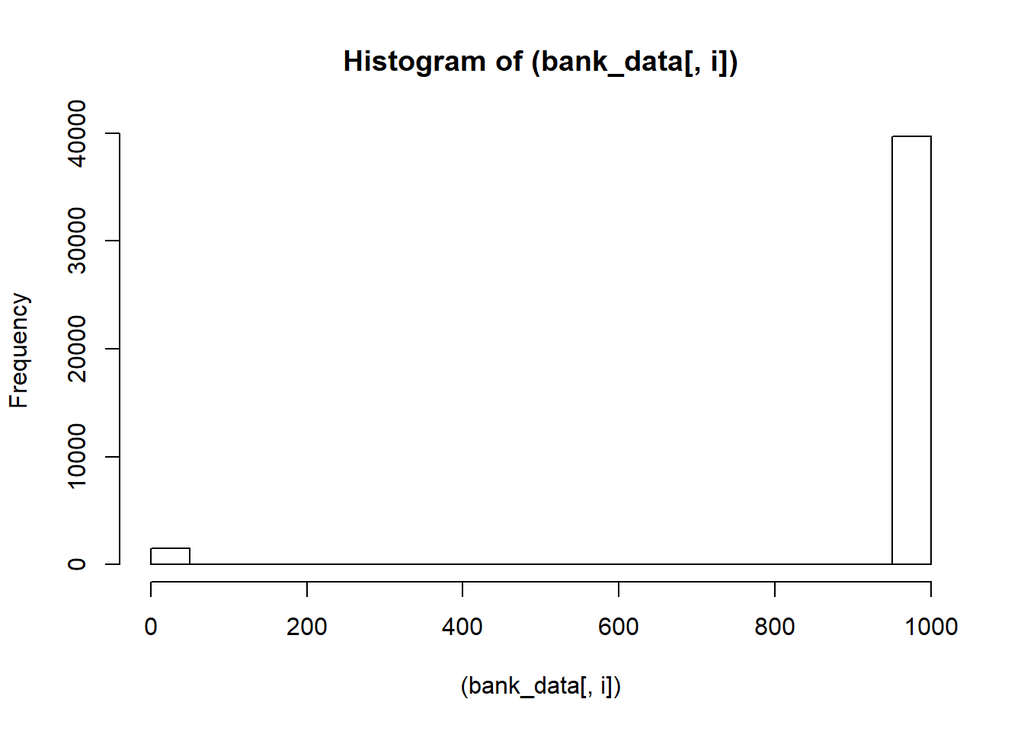

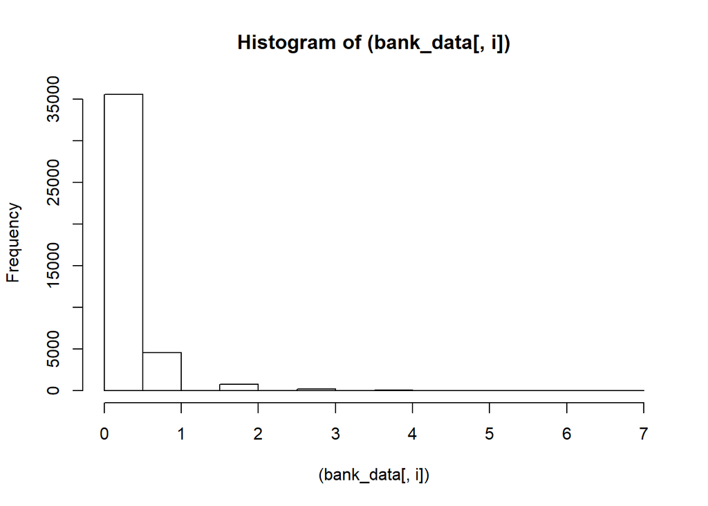

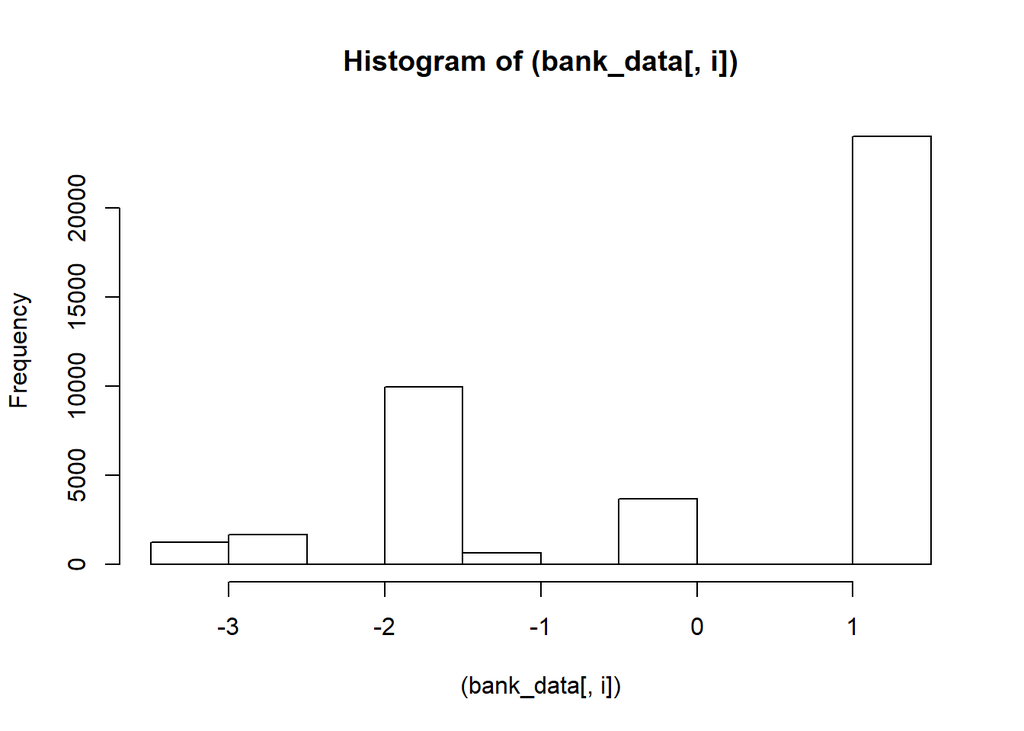

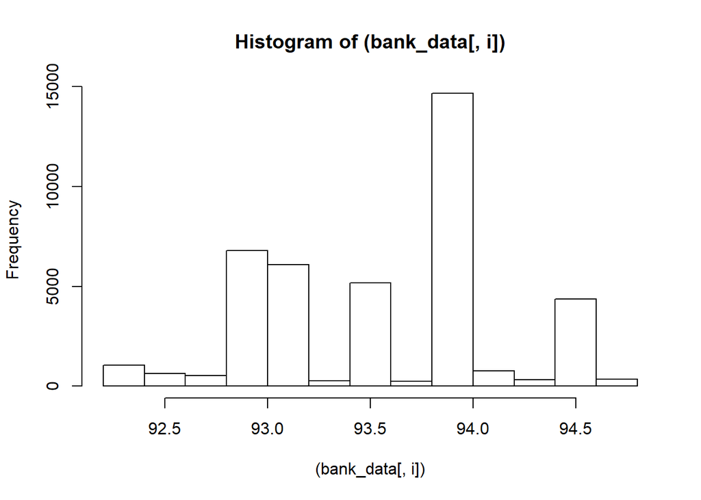

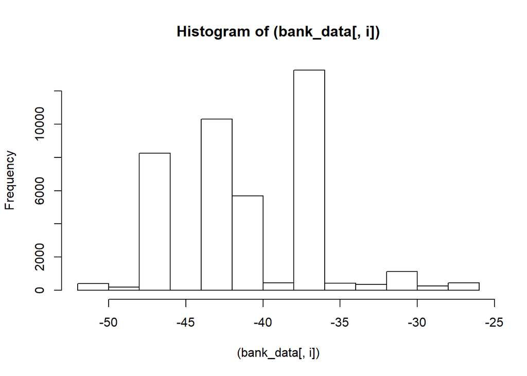

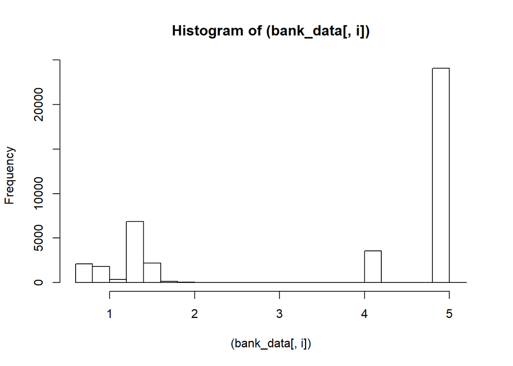

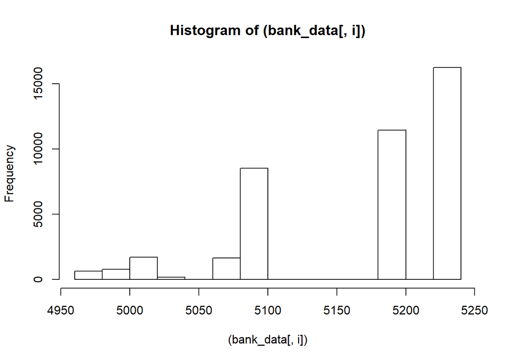

```r
#Plotting Histogram to see the distribution of the data and skewness
for (i in c(1,11,12,13,14,16,17,18,19,20)){
  hist((bank_data[,i]))
}
```

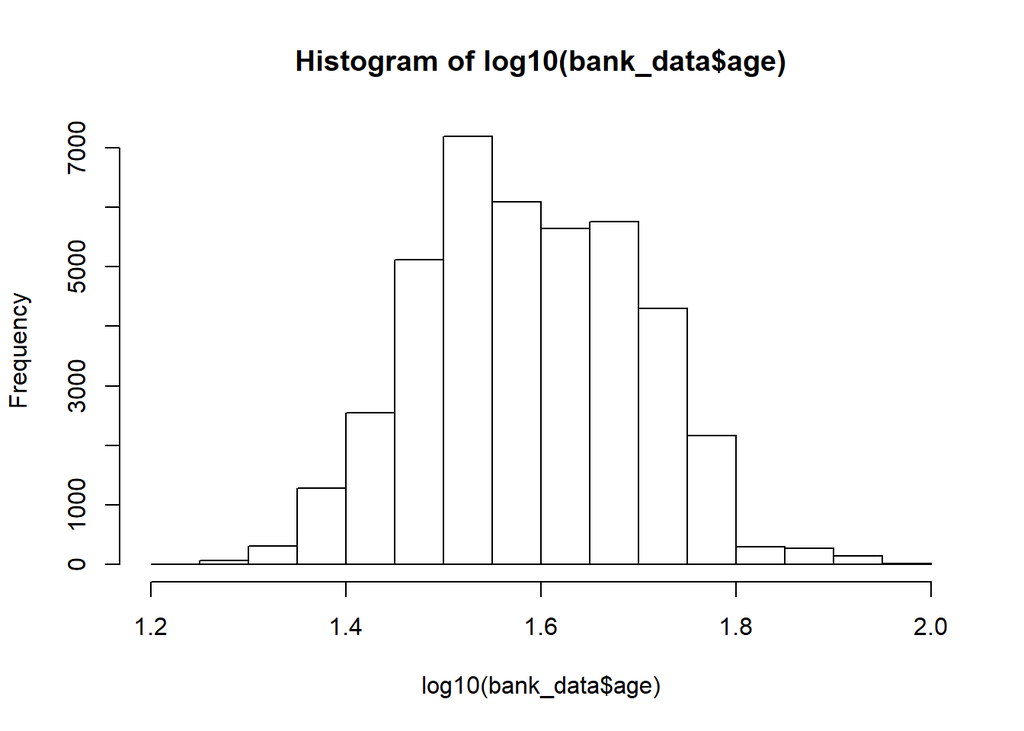

```r
#Transforming Age and Duration data using Log transform
#It is fairly normal after transformation
hist(log10(bank_data$age))
```

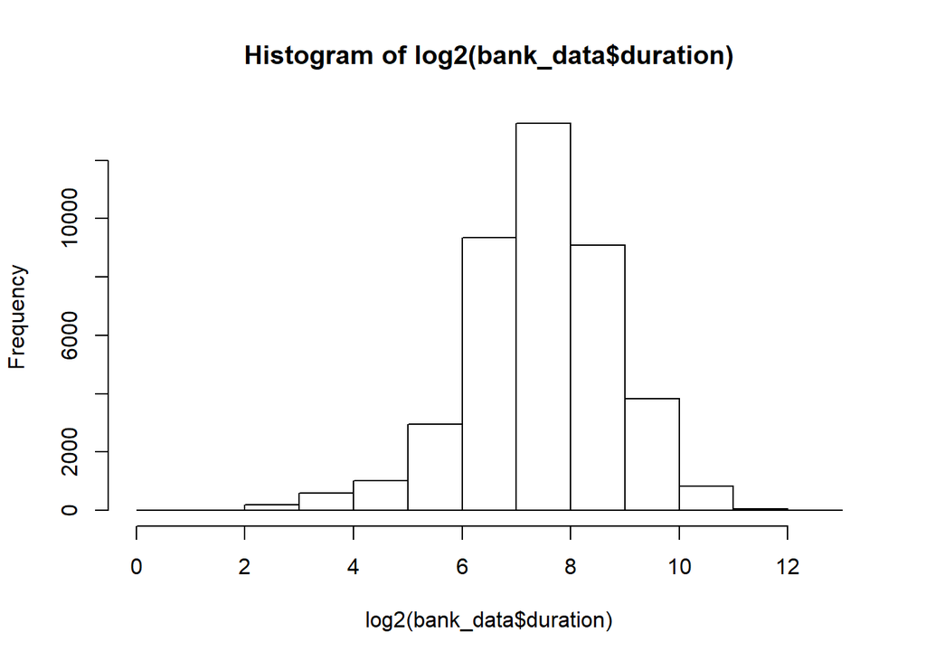

```r
hist(log2(bank_data$duration))
```

```r
#Converting all factor datatype to numeric for neural network model
for (i in 1:ncol(bank_data)){
  if(is.factor( bank_data[,i] )){
    bank_data[,i] <- as.numeric(bank_data[,i])
  }
}

#Verifying structure of data
str(bank_data)
```

```
## 'data.frame':    41188 obs. of  21 variables:
##  $ age           : int  56 57 37 40 56 45 59 41 24 25 ...
##  $ job           : num  4 8 8 1 8 8 1 2 10 8 ...
##  $ marital       : num  2 2 2 2 2 2 2 2 3 3 ...
##  $ education     : num  1 4 4 2 4 3 6 8 6 4 ...
##  $ default       : num  1 2 1 1 1 2 1 2 1 1 ...
##  $ housing       : num  1 1 3 1 1 1 1 1 3 3 ...
##  $ loan          : num  1 1 1 1 3 1 1 1 1 1 ...
##  $ contact       : num  2 2 2 2 2 2 2 2 2 2 ...
##  $ month         : num  7 7 7 7 7 7 7 7 7 7 ...
##  $ day_of_week   : num  2 2 2 2 2 2 2 2 2 2 ...
##  $ duration      : int  261 149 226 151 307 198 139 217 380 50 ...
##  $ campaign      : int  1 1 1 1 1 1 1 1 1 1 ...
##  $ pdays         : int  999 999 999 999 999 999 999 999 999 999 ...
##  $ previous      : int  0 0 0 0 0 0 0 0 0 0 ...
##  $ poutcome      : num  2 2 2 2 2 2 2 2 2 2 ...
##  $ emp.var.rate  : num  1.1 1.1 1.1 1.1 1.1 1.1 1.1 1.1 1.1 1.1 ...
##  $ cons.price.idx: num  94 94 94 94 94 ...
##  $ cons.conf.idx : num  -36.4 -36.4 -36.4 -36.4 -36.4 -36.4 -36.4 -36.4 -36.4 -36.4 ...
##  $ euribor3m     : num  4.86 4.86 4.86 4.86 4.86 ...
##  $ nr.employed   : num  5191 5191 5191 5191 5191 ...
##  $ y             : num  1 1 1 1 1 1 1 1 1 1 ...
```

```r
#Normalizing the dataset using min-max normalization
normalize <- function(x) {
  return((x - min(x)) / (max(x) - min(x)))
}

#Factorizing last predictor column and normalizing other numeric features
bank_data[,-21] <- lapply(bank_data[,-21], normalize)
bank_data[,21] <- as.factor(bank_data[,21])

#Verifying normalization of data
summary(bank_data)
```

```
##       age              job            marital         education
##  Min.   :0.0000   Min.   :0.0000   Min.   :0.0000   Min.   :0.0000
##  1st Qu.:0.1852   1st Qu.:0.0000   1st Qu.:0.3333   1st Qu.:0.2857
##  Median :0.2593   Median :0.1818   Median :0.3333   Median :0.4286
##  Mean   :0.2842   Mean   :0.3386   Mean   :0.3909   Mean   :0.5353
##  3rd Qu.:0.3704   3rd Qu.:0.6364   3rd Qu.:0.6667   3rd Qu.:0.8571
##  Max.   :1.0000   Max.   :1.0000   Max.   :1.0000   Max.   :1.0000
##     default          housing            loan           contact
##  Min.   :0.0000   Min.   :0.0000   Min.   :0.0000   Min.   :0.0000
##  1st Qu.:0.0000   1st Qu.:0.0000   1st Qu.:0.0000   1st Qu.:0.0000
##  Median :0.0000   Median :1.0000   Median :0.0000   Median :0.0000
##  Mean   :0.1044   Mean   :0.5359   Mean   :0.1637   Mean   :0.3653
##  3rd Qu.:0.0000   3rd Qu.:1.0000   3rd Qu.:0.0000   3rd Qu.:1.0000
##  Max.   :1.0000   Max.   :1.0000   Max.   :1.0000   Max.   :1.0000
##      month         day_of_week        duration          campaign
##  Min.   :0.0000   Min.   :0.0000   Min.   :0.00000   Min.   :0.00000
##  1st Qu.:0.3333   1st Qu.:0.2500   1st Qu.:0.02074   1st Qu.:0.00000
##  Median :0.4444   Median :0.5000   Median :0.03660   Median :0.01818
##  Mean   :0.4701   Mean   :0.5012   Mean   :0.05252   Mean   :0.02850
##  3rd Qu.:0.6667   3rd Qu.:0.7500   3rd Qu.:0.06486   3rd Qu.:0.03636
##  Max.   :1.0000   Max.   :1.0000   Max.   :1.00000   Max.   :1.00000
##      pdays           previous          poutcome       emp.var.rate
##  Min.   :0.0000   Min.   :0.00000   Min.   :0.0000   Min.   :0.0000
##  1st Qu.:1.0000   1st Qu.:0.00000   1st Qu.:0.5000   1st Qu.:0.3333
##  Median :1.0000   Median :0.00000   Median :0.5000   Median :0.9375
##  Mean   :0.9634   Mean   :0.02471   Mean   :0.4651   Mean   :0.7254
##  3rd Qu.:1.0000   3rd Qu.:0.00000   3rd Qu.:0.5000   3rd Qu.:1.0000
##  Max.   :1.0000   Max.   :1.00000   Max.   :1.0000   Max.   :1.0000
##  cons.price.idx   cons.conf.idx      euribor3m       nr.employed     y
##  Min.   :0.0000   Min.   :0.0000   Min.   :0.0000   Min.   :0.0000   1:36548
##  1st Qu.:0.3406   1st Qu.:0.3389   1st Qu.:0.1610   1st Qu.:0.5123   2: 4640
##  Median :0.6033   Median :0.3766   Median :0.9574   Median :0.8597
##  Mean   :0.5357   Mean   :0.4309   Mean   :0.6772   Mean   :0.7691
##  3rd Qu.:0.6988   3rd Qu.:0.6025   3rd Qu.:0.9810   3rd Qu.:1.0000
##  Max.   :1.0000   Max.   :1.0000   Max.   :1.0000   Max.   :1.0000
```